# Exploratory Data Analysis. Lab 6: Работа с текстовыми строками. Пакет stringr

Сегодня работаем с текстовыми (строковыми) данными. Сначала немного о различиях между типами (от типа переменной зависит, что мы сможем с ней делать)

# Factors & Strings

## Strings

```r
a <- "Hello"
a
```

```
## [1] "Hello"
```

```r
b <- c("Hello", "World")
b[2]
```

```
## [1] "World"
```

```r
class(a)
```

```
## [1] "character"
```

## Factors

```r
movies <- ggplot2movies::movies
movies <- na.omit(movies)

str(movies)
```

```
## Classes 'tbl_df', 'tbl' and 'data.frame':    5215 obs. of  24 variables:
##  $ title      : chr  "'G' Men" "'Manos' the Hands of Fate" "'Til There Was You" ".com for Murder" ...
##  $ year       : int  1935 1966 1997 2002 1999 2002 1997 1989 2001 2000 ...
##  $ length     : int  85 74 113 96 97 98 94 117 103 100 ...
##  $ budget     : int  450000 19000 23000000 5000000 16000000 1100000 140000 200000 200000 85000000 ...
##  $ rating     : num  7.2 1.6 4.8 3.7 6.7 5.6 3.3 7.8 5.8 4.7 ...
##  $ votes      : int  281 7996 799 271 19095 181 19 299 7 1987 ...
##  $ r1         : num  0 74.5 4.5 64.5 4.5 4.5 14.5 4.5 0 4.5 ...
##  $ r2         : num  4.5 4.5 4.5 4.5 4.5 4.5 14.5 0 0 4.5 ...
##  $ r3         : num  4.5 4.5 4.5 4.5 4.5 4.5 4.5 4.5 14.5 14.5 ...
##  $ r4         : num  4.5 4.5 14.5 4.5 4.5 4.5 14.5 4.5 0 14.5 ...
##  $ r5         : num  4.5 4.5 14.5 4.5 4.5 14.5 14.5 4.5 0 24.5 ...
##  $ r6         : num  14.5 4.5 14.5 4.5 14.5 24.5 14.5 4.5 44.5 14.5 ...
##  $ r7         : num  34.5 4.5 14.5 4.5 24.5 14.5 14.5 4.5 0 14.5 ...
##  $ r8         : num  34.5 4.5 4.5 4.5 14.5 14.5 0 14.5 14.5 4.5 ...
##  $ r9         : num  4.5 4.5 4.5 4.5 14.5 4.5 0 14.5 0 4.5 ...
##  $ r10        : num  4.5 14.5 14.5 4.5 14.5 14.5 24.5 45.5 24.5 4.5 ...
##  $ mpaa       : chr  "" "" "PG-13" "" ...
##  $ Action     : int  0 0 0 0 0 0 0 0 0 0 ...
##  $ Animation  : int  0 0 0 0 0 0 0 0 0 0 ...
##  $ Comedy     : int  0 0 1 0 1 1 0 0 0 1 ...
##  $ Drama      : int  1 0 0 0 0 0 1 0 1 0 ...
##  $ Documentary: int  0 0 0 0 0 0 0 1 0 0 ...
##  $ Romance    : int  0 0 1 0 1 0 0 0 0 0 ...
##  $ Short      : int  0 0 0 0 0 0 0 0 0 0 ...
##  - attr(*, "na.action")=Class 'omit'  Named int [1:53573] 1 2 3 4 5 6 7 8 9 10 ...
##   .. ..- attr(*, "names")= chr [1:53573] "1" "2" "3" "4" ...
```

```r
?ggplot2movies::movies

library(dplyr)
movies2 <- filter(movies, mpaa == "PG" | mpaa == "PG-13" | mpaa == "R" | mpaa == "NC-17")

# factors & numeric (distinctions)
class(movies2$mpaa)
```

```
## [1] "character"
```

```r
summary(movies2$mpaa)
```

```
##    Length     Class      Mode
##      1813 character character
```

```r
class(movies2$rating)
```

```
## [1] "numeric"
```

```r
summary(movies2$rating)
```

```
##    Min. 1st Qu.  Median    Mean 3rd Qu.    Max.
##   1.600   5.100   6.100   5.932   6.900   9.100
```

При преобразовании типов переменных не забывайте сохранять результат

```r
sort(tail(movies2$mpaa, 150))
```

```
##   [1] "NC-17" "NC-17" "PG"    "PG"    "PG"    "PG"    "PG"    "PG"
##   [9] "PG"    "PG"    "PG"    "PG"    "PG"    "PG"    "PG"    "PG"
##  [17] "PG-13" "PG-13" "PG-13" "PG-13" "PG-13" "PG-13" "PG-13" "PG-13"
##  [25] "PG-13" "PG-13" "PG-13" "PG-13" "PG-13" "PG-13" "PG-13" "PG-13"
##  [33] "PG-13" "PG-13" "PG-13" "PG-13" "PG-13" "PG-13" "PG-13" "PG-13"
##  [41] "PG-13" "PG-13" "PG-13" "PG-13" "PG-13" "PG-13" "PG-13" "PG-13"
##  [49] "PG-13" "PG-13" "PG-13" "PG-13" "PG-13" "PG-13" "PG-13" "PG-13"
##  [57] "PG-13" "PG-13" "PG-13" "PG-13" "PG-13" "PG-13" "PG-13" "PG-13"
##  [65] "PG-13" "PG-13" "PG-13" "PG-13" "PG-13" "PG-13" "PG-13" "PG-13"
##  [73] "PG-13" "R"     "R"     "R"     "R"     "R"     "R"     "R"
##  [81] "R"     "R"     "R"     "R"     "R"     "R"     "R"     "R"
##  [89] "R"     "R"     "R"     "R"     "R"     "R"     "R"     "R"
##  [97] "R"     "R"     "R"     "R"     "R"     "R"     "R"     "R"
## [105] "R"     "R"     "R"     "R"     "R"     "R"     "R"     "R"
## [113] "R"     "R"     "R"     "R"     "R"     "R"     "R"     "R"
## [121] "R"     "R"     "R"     "R"     "R"     "R"     "R"     "R"
## [129] "R"     "R"     "R"     "R"     "R"     "R"     "R"     "R"
## [137] "R"     "R"     "R"     "R"     "R"     "R"     "R"     "R"
## [145] "R"     "R"     "R"     "R"     "R"     "R"
```

```r
tail(movies2$mpaa, 150) %>% sort()
```

```
##   [1] "NC-17" "NC-17" "PG"    "PG"    "PG"    "PG"    "PG"    "PG"
##   [9] "PG"    "PG"    "PG"    "PG"    "PG"    "PG"    "PG"    "PG"
##  [17] "PG-13" "PG-13" "PG-13" "PG-13" "PG-13" "PG-13" "PG-13" "PG-13"
##  [25] "PG-13" "PG-13" "PG-13" "PG-13" "PG-13" "PG-13" "PG-13" "PG-13"
##  [33] "PG-13" "PG-13" "PG-13" "PG-13" "PG-13" "PG-13" "PG-13" "PG-13"
##  [41] "PG-13" "PG-13" "PG-13" "PG-13" "PG-13" "PG-13" "PG-13" "PG-13"
##  [49] "PG-13" "PG-13" "PG-13" "PG-13" "PG-13" "PG-13" "PG-13" "PG-13"
##  [57] "PG-13" "PG-13" "PG-13" "PG-13" "PG-13" "PG-13" "PG-13" "PG-13"
##  [65] "PG-13" "PG-13" "PG-13" "PG-13" "PG-13" "PG-13" "PG-13" "PG-13"
##  [73] "PG-13" "R"     "R"     "R"     "R"     "R"     "R"     "R"
##  [81] "R"     "R"     "R"     "R"     "R"     "R"     "R"     "R"
##  [89] "R"     "R"     "R"     "R"     "R"     "R"     "R"     "R"
##  [97] "R"     "R"     "R"     "R"     "R"     "R"     "R"     "R"
## [105] "R"     "R"     "R"     "R"     "R"     "R"     "R"     "R"
## [113] "R"     "R"     "R"     "R"     "R"     "R"     "R"     "R"
## [121] "R"     "R"     "R"     "R"     "R"     "R"     "R"     "R"
## [129] "R"     "R"     "R"     "R"     "R"     "R"     "R"     "R"
## [137] "R"     "R"     "R"     "R"     "R"     "R"     "R"     "R"
## [145] "R"     "R"     "R"     "R"     "R"     "R"
```

```r
movies2$mpaa<- as.factor(movies2$mpaa)
levels(movies2$mpaa)
```

```
## [1] "NC-17" "PG"    "PG-13" "R"
```

```r
sort(tail(movies2$mpaa, 150))
```

```
##   [1] NC-17 NC-17 PG    PG    PG    PG    PG    PG    PG    PG    PG
##  [12] PG    PG    PG    PG    PG    PG-13 PG-13 PG-13 PG-13 PG-13 PG-13
##  [23] PG-13 PG-13 PG-13 PG-13 PG-13 PG-13 PG-13 PG-13 PG-13 PG-13 PG-13
##  [34] PG-13 PG-13 PG-13 PG-13 PG-13 PG-13 PG-13 PG-13 PG-13 PG-13 PG-13
##  [45] PG-13 PG-13 PG-13 PG-13 PG-13 PG-13 PG-13 PG-13 PG-13 PG-13 PG-13
##  [56] PG-13 PG-13 PG-13 PG-13 PG-13 PG-13 PG-13 PG-13 PG-13 PG-13 PG-13
##  [67] PG-13 PG-13 PG-13 PG-13 PG-13 PG-13 PG-13 R     R     R     R
##  [78] R     R     R     R     R     R     R     R     R     R     R
##  [89] R     R     R     R     R     R     R     R     R     R     R
## [100] R     R     R     R     R     R     R     R     R     R     R
## [111] R     R     R     R     R     R     R     R     R     R     R
## [122] R     R     R     R     R     R     R     R     R     R     R
## [133] R     R     R     R     R     R     R     R     R     R     R
## [144] R     R     R     R     R     R     R
## Levels: NC-17 PG PG-13 R
```

Факторы бывают и упорядоченными

```r
# ordered factors
movies2$mpaa <- factor(movies2$mpaa, lab=c("PG", "PG-13", "R", "NC-17"), ordered=T)
sort(tail(movies2$mpaa, 150))
```

```
##   [1] PG    PG    PG-13 PG-13 PG-13 PG-13 PG-13 PG-13 PG-13 PG-13 PG-13
##  [12] PG-13 PG-13 PG-13 PG-13 PG-13 R     R     R     R     R     R
##  [23] R     R     R     R     R     R     R     R     R     R     R
##  [34] R     R     R     R     R     R     R     R     R     R     R
##  [45] R     R     R     R     R     R     R     R     R     R     R
##  [56] R     R     R     R     R     R     R     R     R     R     R
##  [67] R     R     R     R     R     R     R     NC-17 NC-17 NC-17 NC-17
##  [78] NC-17 NC-17 NC-17 NC-17 NC-17 NC-17 NC-17 NC-17 NC-17 NC-17 NC-17
##  [89] NC-17 NC-17 NC-17 NC-17 NC-17 NC-17 NC-17 NC-17 NC-17 NC-17 NC-17
## [100] NC-17 NC-17 NC-17 NC-17 NC-17 NC-17 NC-17 NC-17 NC-17 NC-17 NC-17
## [111] NC-17 NC-17 NC-17 NC-17 NC-17 NC-17 NC-17 NC-17 NC-17 NC-17 NC-17
## [122] NC-17 NC-17 NC-17 NC-17 NC-17 NC-17 NC-17 NC-17 NC-17 NC-17 NC-17
## [133] NC-17 NC-17 NC-17 NC-17 NC-17 NC-17 NC-17 NC-17 NC-17 NC-17 NC-17
## [144] NC-17 NC-17 NC-17 NC-17 NC-17 NC-17 NC-17
## Levels: PG < PG-13 < R < NC-17
```

```r
head(movies2$mpaa)
```

```
## [1] R     R     NC-17 R     NC-17 NC-17
## Levels: PG < PG-13 < R < NC-17
```

```r
# look at levels
head(factor(movies2$mpaa, levels=rev(levels(movies2$mpaa))))
```

```
## [1] R     R     NC-17 R     NC-17 NC-17
## Levels: NC-17 < R < PG-13 < PG
```

```r
levels(movies2$mpaa)
```

```
## [1] "PG"    "PG-13" "R"     "NC-17"
```

```r
rev(levels(movies2$mpaa))
```

```
## [1] "NC-17" "R"     "PG-13" "PG"
```

# Работа со строками

Теперь загрузим пакет stringr, с помощью которого будем учиться работать со строками. Подробнее [тут](https://cran.r-project.org/web/packages/stringr/vignettes/stringr.html)

С помощью этого пакета можно соединять (склеивать) строки, искать в них элементы по шаблону, заменять и извлекать части строк, считать длину строки и т.д.

```r
library(stringr)
```

### Простая обработка

Рассмотрим сначала простой пример

```r
my_text <- c(
  " First sentence  ",
  " Second Sentence ",
  " 3rd sentence ",
  " so text.. much sense"
)
my_text
```

```
## [1] " First sentence  "     " Second Sentence "     " 3rd sentence "
## [4] " so text.. much sense"
```

Посчитаем длины строк

```r
str_length(my_text)
```

```
## [1] 17 17 14 21
```

Соединим все в одну строку

```r
str_c(my_text, collapse="") #join multiple strings into a single string
```

```
## [1] " First sentence   Second Sentence  3rd sentence  so text.. much sense"
```

Добавим одинаковый текст

```r
str_c("Example:", my_text)
```

```
## [1] "Example: First sentence  "     "Example: Second Sentence "
## [3] "Example: 3rd sentence "        "Example: so text.. much sense"
```

```r
str_c("1", " text ", "2")
```

```
## [1] "1 text 2"
```

Уберем лишние пробелы

```r
str_trim(my_text)
```

```
## [1] "First sentence"       "Second Sentence"      "3rd sentence"
## [4] "so text.. much sense"
```

Сравним два результата

```r
str_c(str_trim(my_text), collapse="&")
```

```
## [1] "First sentence&Second Sentence&3rd sentence&so text.. much sense"
```

```r
str_c(str_trim(my_text), collapse=" & ")
```

```
## [1] "First sentence & Second Sentence & 3rd sentence & so text.. much sense"
```

### Обнаружение паттернов

Попробуем найти текст по образцу

```r
str_detect(my_text, "3")
```

```
## [1] FALSE FALSE  TRUE FALSE
```

```r
str_detect(my_text, "S")
```

```
## [1] FALSE  TRUE FALSE FALSE
```

```r
str_detect(my_text, "sentence")
```

```
## [1]  TRUE FALSE  TRUE FALSE
```

```r
str_extract(my_text, "sentence") #Extract matching patterns from a string.
```

```
## [1] "sentence" NA         "sentence" NA
```

В чем отличие str_extract от str_detect? (Читать справку всегда полезно!)

```r
str_extract("Data scientist is the sexiest job of 21st centure!!!", "[0-9]")
```

```
## [1] "2"
```

```r
str_extract("Data scientist is the sexiest job of 21st centure!!!", "[0-9][0-9]")
```

```
## [1] "21"
```

```r
str_extract("Data scientist is the sexiest job of 21st centure!!!", "[0-9][0-9][0-9]")
```

```
## [1] NA
```

```r
str_extract("Data scientist is the sexiest job of 21st centure!!!", "[а-я]")
```

```
## [1] NA
```

```r
str_detect("Data scientist is the sexiest job of 21st centure!!!", "[a-e]")
```

```
## [1] TRUE
```

```r
str_extract("Data scientist is the sexiest job of 21st centure!!!", "[a-e]")
```

```
## [1] "a"
```

```r
str_extract_all("Data scientist is the sexiest job of 21st centure!!!", "[a-e]")
```

```
## [[1]]
##  [1] "a" "a" "c" "e" "e" "e" "e" "b" "c" "e" "e"
```

```r
text = c("Machine learning", "Data Science", "Visualization")
str_extract_all(text, "[a-b]")
```

```
## [[1]]
## [1] "a" "a"
##
## [[2]]
## [1] "a" "a"
##
## [[3]]
## [1] "a" "a"
```

```r
str_count(text, "c")
```

```
## [1] 1 2 0
```

Посмотрим, в скольких названиях фильмов встречается слово Book

```r
books = str_detect(movies$title, "Book")
sum(books)
```

```
## [1] 10
```

```r
books = str_detect(movies$title, "book")
sum(books)
```

```
## [1] 2
```

```r
books = str_detect(movies$title, "book|Book")
sum(books)
```

```
## [1] 12
```

Последнее можно сделать и немного по-другому: приведем все названия к одному регистру

Посмотрим сначала на примере 10 фильмов с наибольшим числом голосов

```r
moviesCut = movies %>% top_n(votes, n = 10)
moviesCut$title
```

```
##  [1] "American Beauty"
##  [2] "Fight Club"
##  [3] "Godfather, The"
##  [4] "Lord of the Rings: The Fellowship of the Ring, The"
##  [5] "Lord of the Rings: The Two Towers, The"
##  [6] "Matrix, The"
##  [7] "Pulp Fiction"
##  [8] "Shawshank Redemption, The"
##  [9] "Star Wars"
## [10] "Usual Suspects, The"
```

```r
str_to_lower(moviesCut$title)
```

```
##  [1] "american beauty"
##  [2] "fight club"
##  [3] "godfather, the"
##  [4] "lord of the rings: the fellowship of the ring, the"
##  [5] "lord of the rings: the two towers, the"
##  [6] "matrix, the"
##  [7] "pulp fiction"
##  [8] "shawshank redemption, the"
##  [9] "star wars"
## [10] "usual suspects, the"
```

```r
str_to_upper(moviesCut$title)
```

```
##  [1] "AMERICAN BEAUTY"
##  [2] "FIGHT CLUB"
##  [3] "GODFATHER, THE"
##  [4] "LORD OF THE RINGS: THE FELLOWSHIP OF THE RING, THE"
##  [5] "LORD OF THE RINGS: THE TWO TOWERS, THE"
##  [6] "MATRIX, THE"
##  [7] "PULP FICTION"
##  [8] "SHAWSHANK REDEMPTION, THE"
##  [9] "STAR WARS"
## [10] "USUAL SUSPECTS, THE"
```

```r
str_to_title(moviesCut$title)
```

```
##  [1] "American Beauty"
##  [2] "Fight Club"
##  [3] "Godfather, The"
##  [4] "Lord Of The Rings: The Fellowship Of The Ring, The"
##  [5] "Lord Of The Rings: The Two Towers, The"
##  [6] "Matrix, The"
##  [7] "Pulp Fiction"
##  [8] "Shawshank Redemption, The"
##  [9] "Star Wars"
## [10] "Usual Suspects, The"
```

Слово book в названии:

```r
books = str_detect(str_to_lower(movies$title), "book")
sum(books)
```

```
## [1] 12
```

А теперь посчитаем средний рейтинг фильмов со словом book в названии и без него

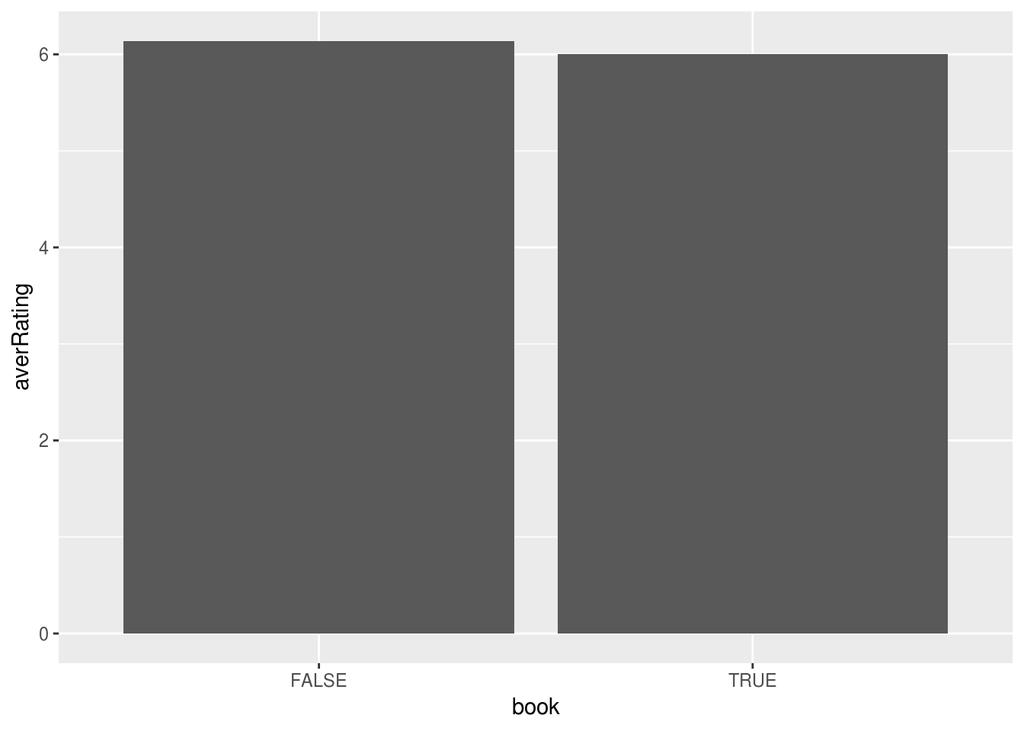

```r
movies$book = books
library(ggplot2)
movies %>%
  group_by(book) %>%
  dplyr::summarise(averRating = mean(rating)) %>%
  ggplot() + geom_bar(aes(x = book, y = averRating), stat = "identity")
```

### Изменение текста

```r
str_split("Data scientist is the sexiest job of 21st centure!!!!", " ")
```

```
## [[1]]
## [1] "Data"        "scientist"   "is"          "the"         "sexiest"
## [6] "job"         "of"          "21st"        "centure!!!!"
```

```r
str_replace("Data scientist is the sexiest job of 21st centure!!!", "!!!", "")
```

```
## [1] "Data scientist is the sexiest job of 21st centure"
```

```r
# а что если надо заменить паттерн, повторяющийся в строке несколько раз?
str_replace("Data scientist is the sexiest job of 21st centure!!!", "s", "$")
```

```
## [1] "Data $cientist is the sexiest job of 21st centure!!!"
```

```r
str_replace_all("Data scientist is the sexiest job of 21st centure!!!", "s", "$")
```

```
## [1] "Data $cienti$t i$ the $exie$t job of 21$t centure!!!"
```

**Ваша очередь**

1. Посчитайте, сколько названий содержат цифры
2. Постройте график, показывающий связь цифр в названии и рейтинга фильма
3. Постройте график, показывающий связь длины названия (str_length) и рейтинга фильма
4. Отберите 150 фильмов с наибольшим числом голосов, из них оставьте 100 с наивысшим рейтингом. повторите для них п.1-3

Продолжим работать с базой сообщений очевидцев НЛО. Прошлый раз мы совсем не использовали последний столбец с описанием. Посмотрим на него сегодня подробнее

Загружаем данные.

```r
library(readr)
ufo = read_csv("~/shared/minor2_2018/1-intro/data/ufo.csv")
# naming columns
colnames(ufo) = c("Sighted", "Reported", "Location", "Shape", "Duration", "Description")

# stringr как инструмент очистки баз от шума

ufo$Description <- str_replace_all(ufo$Description, "&amp", " ")
```

- Удалите другие, лишние на ваш взляд, слова и/или символы
- Посмотрите, встречаются ли в описании слова, которые помогут определить пол очевидца (woman, female, girl), не забудьте про регистр. Создайте новую переменную, которая будет показывать, встретилось ли хотя бы одно из таких слов
- Постройте график, показывающий связь между полом (очень приближенно определенным – по встречающимся словам) и разницей между временем наблюдения и временем отчета (см. предыдущую лабораторную)
- Опишите свои выводы в отчете в формате Rmd ([напоминание о создании отчета](https://www.rstudio.com/wp-content/uploads/2015/02/rmarkdown-cheatsheet.pdf))